# Ideological Self-Placement in ANES

A fifth of Americans decline to place themselves, and the survey invited them to

Democracy’s Data

Last updated September 13, 2026 at 10:53a EDT

America is a conservative country. You have heard that claim, usually backed by a poll: self-described conservatives outnumber self-described liberals, and they have for as long as anyone has asked.[^1] Is it true? The answer depends on a question, and the question contains something the headline never mentions.

Ask Americans to place themselves from extremely liberal to extremely conservative and about a fifth of them will decline. That is not a refusal, and it is not missing data. **The survey offers them the exit, out loud, as part of the question.** The result is a scale with two things in the middle: the people who chose the midpoint, and the people who would not choose at all. They sit next to each other in the distribution and they are different in almost every way the file can measure.

## The test

The measure is ideological **self-placement** — where a person puts themself on a scale from extremely liberal to extremely conservative — from the ANES Time Series Cumulative Data File, 1972–2024, obtained from the [American National Election Studies](https://electionstudies.org/data-center/anes-time-series-cumulative-data-file/). The question has been on the study since 1972, in 22 studies, and it is the standard measure of ideology in American survey research. The ANES chapter introduces the cumulative file and the codebook — the document that says what every number in every column means — that this brief depends on.

Only a survey can hold this question, because ideology has no administrative existence. There is no register of liberals; the thing exists only as something people say in response to specific words. And no election ever grades the answer, the way a vote poll is eventually graded by a count, so the question’s construction is not a detail sitting under the measurement — it *is* the measurement. The series can be read across five decades only because ANES kept the wording and the coding fixed on purpose, study after study.

The test has two parts. First, follow all four shares (liberal, moderate, conservative, and *declined to place*) from 1972 to 2024, and see which of them the conservative-country claim survives. Second, compare the two middles head to head, because whether they can be merged decides what “moderate America” even means.

## The data

The cumulative file carries the answer as `VCF0803` — the file’s own label for the question — one column with seven scale codes and one more. Here is the question as the interviewer reads it, and the codebook’s own accounting of the codes.

```
The question, as the interviewer reads it:

  We hear a lot of talk these days about liberals and conservatives.
  Here is a 7-point scale on which the political views that people
  might hold are arranged from extremely liberal to extremely
  conservative. Where would you place yourself on this scale,
  OR HAVEN'T YOU THOUGHT MUCH ABOUT THIS?

The codebook's own Valid block -- note where 9 appears:

  Valid   1. Extremely liberal
          2. Liberal
          3. Slightly liberal
          4. Moderate, middle of the road
          5. Slightly conservative
          6. Conservative
          7. Extremely conservative
          9. DK; haven't thought much about it

  Missing 0. NA; no Post IW; form III,IV (1972); R not administered

Five random rows as they arrive:

year  VCF0803  means  VCF0804
1986  6  Conservative  3
1990  2  Liberal  1
2016  2  Liberal  1
2020  4  Moderate, middle of the road  2
2024  4  Moderate, middle of the road  NA

A 9 is not a gap in the data. It is an answer to the question that
was asked, and the codebook files it under Valid.
```

Read the question again. The interviewer does not ask where you place yourself and then record a shrug. The interviewer asks *“…or haven’t you thought much about this?”* — offering the alternative in the same breath as the scale.

Then look at where the codebook files the answer. Code 9 is in the **Valid** block. Code 0, meaning no interview or not administered, is in Missing. ANES has decided that “haven’t thought much about it” is a response, and a person who drops the nines as missing data is not cleaning the file. They are overruling its classification of what counts as an answer.

Three tables are built from this. `placement.csv` gives every study year’s share in four groups: `liberal` (codes 1–3), `moderate` (code 4), `conservative` (codes 5–7), and `not_placed` (code 9), with the year’s `n`. `middles.csv` compares moderates and non-placers on what the file can measure about them: education from `VCF0110`, turnout from `VCF0703`, strength of partisanship from `VCF0301`, interest in the campaign from `VCF0310`. `collapse.csv` records what the convenience column `VCF0804`, the file’s own three-category version of the answer, does with each code. Only code 0 is dropped anywhere; nothing is weighted, a choice discussed below. In the pooled file, 12,457 respondents took the exit and 13,772 placed themselves at the midpoint, so the exit-takers are 47.5% of the two middles combined.

> **Before you read on, commit to a view.** You are computing a mean ideology score for each state. **What do you do with the nines — drop them, score them as 4, or something else?** Whichever you pick, say what your answer would mean if it turned out the nines are concentrated in particular states.

## What it says about democracy

Start with the two middles, because every count of liberals and conservatives depends on what you do with them.

| Measure | Moderate | Havent thought much |
| --- | --- | --- |
| Holds a college degree | 25.2% | 7.7% |
| Voted | 52.0% | 39.4% |
| Very much interested in the campaign | 33.3% | 21.4% |
| Pure independent, no party at all | 17.0% | 20.5% |
| Strong partisan, strong Democrat or strong Republican | 23.0% | 27.7% |
| Abortion should always be permitted | 48.4% | 36.4% |
| Mean position on government health insurance (1-7) | 3.7 | 3.5 |

The largest gap is education, and it is not close: **25.2% of moderates hold a college degree against 7.7% of non-placers**, a difference of more than three to one. Non-placers vote less (39.4% against 52.0%) and follow campaigns less closely. None of that is surprising. The liberal-conservative scale is a piece of specialist vocabulary, and declining to use it tracks the things that predict familiarity with specialist vocabulary.

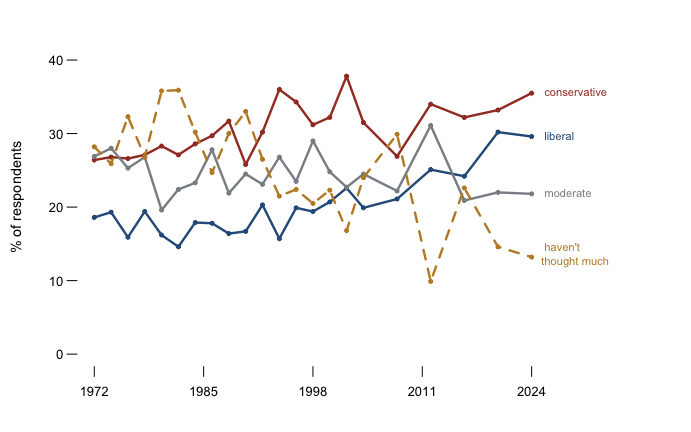

**Figure 1. Ideological self-placement, 1972–2024.** Four lines on one time axis, because the question is where a fixed total went: when one series falls, the form shows which of the others caught it. Hovering reads all four shares at any year. Follow *haven’t thought much* down and watch what is left — as it falls, the two wings grow and the midpoint does not.

Now the conservative-country claim. In 2024, conservatives are 35.5% of respondents and liberals 29.6%, so the label *conservative* does outnumber the label *liberal*, as it has in every study here. But neither label comes near a majority, and the claim quietly ignores the 13.2% who declined the vocabulary altogether. The country the headline describes is the part of the country willing to use these two words.

And the middle has a history the headline also misses. In 1972, 28.2% of respondents would not place themselves; by 2024 it is 13.2% — a fall of 15.0 points. Where did they go? Not to the middle. Moderates went from 26.9% to 21.8%, slightly **down**.

Liberals rose 11.0 points and conservatives rose 9.1. The ideological vocabulary spread through the public over fifty years, and the people who acquired it did not settle in the center. Whether they learned where they already stood, or learning the words taught them where to stand, is a question this file cannot answer.

The file itself takes a position on the nines, and it is worth reading.

| Seven point | Collapses to | Respondents |
| --- | --- | --- |
| 1 Extremely liberal | 1 Liberal | 1,237 |
| 2 Liberal | 1 Liberal | 4,748 |
| 3 Slightly liberal | 1 Liberal | 4,743 |
| 4 Moderate, middle of the road | 1 Liberal | 118 |
| 5 Slightly conservative | 1 Liberal | 35 |
| 6 Conservative | 1 Liberal | 14 |
| 7 Extremely conservative | 1 Liberal | 1 |
| 9 (haven’t thought much) | 1 Liberal | 88 |
| 1 Extremely liberal | 2 Moderate | 3 |
| 2 Liberal | 2 Moderate | 32 |
| 3 Slightly liberal | 2 Moderate | 68 |
| 4 Moderate, middle of the road | 2 Moderate | 12,075 |
| 5 Slightly conservative | 2 Moderate | 95 |
| 6 Conservative | 2 Moderate | 32 |
| 7 Extremely conservative | 2 Moderate | 5 |
| 9 (haven’t thought much) | 2 Moderate | 222 |
| 1 Extremely liberal | 3 Conservative | 1 |
| 2 Liberal | 3 Conservative | 6 |
| 3 Slightly liberal | 3 Conservative | 18 |
| 4 Moderate, middle of the road | 3 Conservative | 144 |
| 5 Slightly conservative | 3 Conservative | 6,412 |
| 6 Conservative | 3 Conservative | 7,387 |
| 7 Extremely conservative | 3 Conservative | 1,556 |
| 9 (haven’t thought much) | 3 Conservative | 107 |
| 9 (haven’t thought much) | 9 (haven’t thought much) | 9,568 |

Note what the collapse does **not** do. The nines survive as their own category: ANES declined to fold them into the moderates, so the convenience column preserves the distinction this brief is about. Hold that next to the party identification brief, because the same file makes the opposite choice one variable away. Party ID’s convenience column, `VCF0303`, folds the leaners into the parties and says so only in a note. One design decision preserved a judgment call; the other resolved it silently. Both are defensible, and neither is announced anywhere a hurried user would look.

## What this brief cannot tell you

The comparison of the two middles pools every study year from 1972 onward, so it describes the two groups on average across five decades rather than today. The education gap in particular should be read against a country where the share of adults with degrees rose throughout the period.

Nothing here is weighted; `VCF0009z` sits in the file unused. Every percentage describes ANES respondents rather than the country, and that matters most for exactly the kind of level claim this brief interrogates: what share of America is conservative.

Self-placement is not the only way to measure ideology, and it may not be the best one. A long literature builds *operational* ideology from issue positions instead — as against the *symbolic* ideology of the label a person chooses — and finds that many self-described conservatives take liberal positions on specific policies.[^2] This brief deliberately does not go there: it is about what one question does, and adding a second measure would change the subject from measurement to the thing measured.

Finally, “haven’t thought much about it” is what the respondent said, not necessarily what is true of them. Some of those 12,457 people have thought about it a great deal and rejected the frame. The file records an answer to a question; it does not record a state of mind.

## What you should have learned

- The scale has two middles: 13,772 respondents chose the midpoint and 12,457 declined to place themselves, and the second group is 47.5% of the two combined.
- The two middles are different people: 25.2% of moderates hold a degree against 7.7% of non-placers, yet non-placers are *more* likely to be strong partisans, 27.7% against 23.0%.
- Conservatives outnumber liberals in 2024, 35.5% to 29.6%, but neither is close to a majority and 13.2% declined the vocabulary entirely.
- The non-placers fell 15.0 points since 1972 and the moderates did not grow; the vocabulary spread to the wings.
- The refusal is data: the codebook files code 9 under Valid, and dropping the nines overrules the file’s own classification of what counts as an answer.

## Extensions

None of these is answered above, and every one can be answered from the tables the Sources section hands over.

- `placement.csv` keeps `moderate` and `not_placed` as separate columns for every year. Plot them together. Are the people in the middle and the people who refuse the question moving the same way?
- `middles.csv` sets the two middles side by side, one `measure` per row. Decide which of them belongs in a headline about moderate America, and write the sentence you would stand behind.
- `collapse.csv` shows how the seven-point answers fold into three, with each group’s `respondents`. Find where the folding is doing the most work. Who disappears when a survey reports three categories?
- Sort `placement.csv` by `not_placed`. Find the years where declining is most common. Is that a change in the public, or in how the question was put?

Two stretch ideas point past the spreadsheet. The General Social Survey asks a near-identical question, `polviews`, in a file anyone can download from NORC (https://gss.norc.org/us/en/gss/get-the-data.html) — rebuild Figure 1 from it and check whether the non-placers shrink there too. And pick one policy question from the ANES file, such as government health insurance (`VCF0806`), and test the operational-ideology critique: how many self-placed conservatives take the liberal side of it?

## Sources

**Data**

- American National Election Studies. *ANES Time Series Cumulative Data File (1948–2024)*, version of 5 February 2026. Ann Arbor, MI and Palo Alto, CA: University of Michigan and Stanford University. https://electionstudies.org/data-center/anes-time-series-cumulative-data-file/
- ANES. *Time Series Cumulative Data File Codebook*, same release. The question wording and the placement of code 9 in the Valid block are quoted directly.

**Academic literature**

- Converse, Philip E. (1964). “The Nature of Belief Systems in Mass Publics,” in David E. Apter, ed., *Ideology and Discontent.* Free Press.
- Ellis, Christopher and James A. Stimson (2012). *Ideology in America.* Cambridge University Press. The symbolic-versus-operational distinction this brief sets aside. https://doi.org/10.1017/CBO9781139094009
- Kinder, Donald R. and Nathan P. Kalmoe (2017). *Neither Liberal nor Conservative: Ideological Innocence in the American Public.* University of Chicago Press. https://press.uchicago.edu/ucp/books/book/chicago/N/bo25841664.html
- Gallup (2023). “U.S. Political Ideology Steady; Conservatives, Moderates Tie.” https://news.gallup.com/poll/467888/political-ideology-steady-conservatives-moderates-tie.aspx

**The data itself**

Every figure above is drawn from these tables. They are plain CSV, they open in a spreadsheet, and they are yours to take further.

`collapse.csv`, `middles.csv`, `placement.csv`

[^1]: Gallup, which has asked its own version of the question since 1992, reports conservatives ahead of liberals throughout: “U.S. Political Ideology Steady; Conservatives, Moderates Tie,” 12 January 2023, https://news.gallup.com/poll/467888/political-ideology-steady-conservatives-moderates-tie.aspx.
[^2]: Christopher Ellis and James A. Stimson, *Ideology in America* (Cambridge: Cambridge University Press, 2012), https://doi.org/10.1017/CBO9781139094009.